# QTM 151 - Quiz 2

## Try to submit as an HTML file

Print your name below

```python
# Write your answer here
print("Angie Siaca")
```

```
Angie Siaca
```

This quiz is open book

- You can use the lecture notes
- You will get partial credit for attempting the questions
- To get full credit, the code should run as intended
- You should NOT communicate with other students

Print the following message:

"I will abide by Emory's code of conduct"

```python
# Write your answer here:
print("I will abide by Emory's code of conduct.")
```

```
I will abide by Emory's code of conduct.
```

Import the libraries "numpy", "matplotlib.pyplot",  
"pandas", "statsmodels.api" and "statsmodels.formula.api"

```python
# Write your answer here
import numpy as np
import matplotlib.pyplot as plt
import pandas as pd
import statsmodels.api as sm
import statsmodels.formula.api as smf
```

Read the dataset "data_quiz/fifa23_players_basic.csv"

- It's a dataset on professional soccer players
- Rows correspond to players (18,539)
- Columns contain attributes of players (32)
- Try to view the dataset before starting

to get a sense of its content

```python
# Write your own code
# Create a dataframe
fifa = pd.read_csv("data_quiz/fifa23_players_basic.csv")
fifa.head()
```

|  | Unnamed: 0 | Known As | Full Name | Overall | Potential | Value(in Euro) | Positions Played | Best Position | Nationality | Image Link | ... | Preferred Foot | Weak Foot Rating | Skill Moves | International Reputation | National Team Name | National Team Image Link | National Team Position | National Team Jersey Number | Attacking Work Rate | Defensive Work Rate |
| --- | --- | --- | --- | --- | --- | --- | --- | --- | --- | --- | --- | --- | --- | --- | --- | --- | --- | --- | --- | --- | --- |
| 0 | 0 | L. Messi | Lionel Messi | 91 | 91 | 54000000 | RW | CAM | Argentina | https://cdn.sofifa.net/players/158/023/23_60.png | ... | Left | 4 | 4 | 5 | Argentina | https://cdn.sofifa.net/flags/ar.png | RW | 10 | Low | Low |
| 1 | 1 | K. Benzema | Karim Benzema | 91 | 91 | 64000000 | CF,ST | CF | France | https://cdn.sofifa.net/players/165/153/23_60.png | ... | Right | 4 | 4 | 4 | France | https://cdn.sofifa.net/flags/fr.png | ST | 19 | Medium | Medium |
| 2 | 2 | R. Lewandowski | Robert Lewandowski | 91 | 91 | 84000000 | ST | ST | Poland | https://cdn.sofifa.net/players/188/545/23_60.png | ... | Right | 4 | 4 | 5 | Poland | https://cdn.sofifa.net/flags/pl.png | ST | 9 | High | Medium |
| 3 | 3 | K. De Bruyne | Kevin De Bruyne | 91 | 91 | 107500000 | CM,CAM | CM | Belgium | https://cdn.sofifa.net/players/192/985/23_60.png | ... | Right | 5 | 4 | 4 | Belgium | https://cdn.sofifa.net/flags/be.png | RF | 7 | High | High |
| 4 | 4 | K. Mbappé | Kylian Mbappé | 91 | 95 | 190500000 | ST,LW | ST | France | https://cdn.sofifa.net/players/231/747/23_60.png | ... | Right | 4 | 5 | 4 | France | https://cdn.sofifa.net/flags/fr.png | ST | 10 | High | Low |

5 rows × 33 columns

(a) Use queries

- Browse the dataset and search for the height variable in cm (centimeters).
- Subset the players whose value of the height variable is above 175

and store it in a new dataset

- How many players are above this height threshold?

HINT: Remember that there is a special syntax for  
when the column names have spaces (see Lecture 10)  
and when the value is a string. See example provided.

```python
# Write your own code

# Example: The following code filters whether
# observations for which `On Loan` is equal to yes
# dataset.query(' `On Loan` == "YES" ')
# Note: be careful with using backward quotations ` here.
# Now apply this to your own example, and calculate the total number of observations.

#fifa[fifa['Height(in cm)']>175]
fifa.query('`Height(in cm)` > 175')
```

|  | Unnamed: 0 | Known As | Full Name | Overall | Potential | Value(in Euro) | Positions Played | Best Position | Nationality | Image Link | ... | Preferred Foot | Weak Foot Rating | Skill Moves | International Reputation | National Team Name | National Team Image Link | National Team Position | National Team Jersey Number | Attacking Work Rate | Defensive Work Rate |
| --- | --- | --- | --- | --- | --- | --- | --- | --- | --- | --- | --- | --- | --- | --- | --- | --- | --- | --- | --- | --- | --- |
| 1 | 1 | K. Benzema | Karim Benzema | 91 | 91 | 64000000 | CF,ST | CF | France | https://cdn.sofifa.net/players/165/153/23_60.png | ... | Right | 4 | 4 | 4 | France | https://cdn.sofifa.net/flags/fr.png | ST | 19 | Medium | Medium |
| 2 | 2 | R. Lewandowski | Robert Lewandowski | 91 | 91 | 84000000 | ST | ST | Poland | https://cdn.sofifa.net/players/188/545/23_60.png | ... | Right | 4 | 4 | 5 | Poland | https://cdn.sofifa.net/flags/pl.png | ST | 9 | High | Medium |
| 3 | 3 | K. De Bruyne | Kevin De Bruyne | 91 | 91 | 107500000 | CM,CAM | CM | Belgium | https://cdn.sofifa.net/players/192/985/23_60.png | ... | Right | 5 | 4 | 4 | Belgium | https://cdn.sofifa.net/flags/be.png | RF | 7 | High | High |
| 4 | 4 | K. Mbappé | Kylian Mbappé | 91 | 95 | 190500000 | ST,LW | ST | France | https://cdn.sofifa.net/players/231/747/23_60.png | ... | Right | 4 | 5 | 4 | France | https://cdn.sofifa.net/flags/fr.png | ST | 10 | High | Low |
| 6 | 6 | T. Courtois | Thibaut Courtois | 90 | 91 | 90000000 | GK | GK | Belgium | https://cdn.sofifa.net/players/192/119/23_60.png | ... | Left | 3 | 1 | 4 | Belgium | https://cdn.sofifa.net/flags/be.png | GK | 1 | Medium | Medium |
| ... | ... | ... | ... | ... | ... | ... | ... | ... | ... | ... | ... | ... | ... | ... | ... | ... | ... | ... | ... | ... | ... |
| 18530 | 18530 | S. Bag | Sajal Bag | 48 | 61 | 110000 | CM,RM | RM | India | https://cdn.sofifa.net/players/270/739/23_60.png | ... | Right | 4 | 2 | 1 | - | - | - | - | Medium | Medium |
| 18531 | 18531 | Liao Wei | Wei Liao | 48 | 54 | 70000 | RM,LM | CDM | China PR | https://cdn.sofifa.net/players/257/691/23_60.png | ... | Right | 3 | 2 | 1 | - | - | - | - | Medium | Medium |
| 18532 | 18532 | H. Singh | Harmanpreet Singh | 48 | 56 | 100000 | ST | ST | India | https://cdn.sofifa.net/players/259/745/23_60.png | ... | Right | 2 | 2 | 1 | - | - | - | - | Medium | Low |
| 18537 | 18537 | D. McCallion | Daithí McCallion | 47 | 61 | 100000 | CB | CB | Republic of Ireland | https://cdn.sofifa.net/players/267/824/23_60.png | ... | Right | 3 | 2 | 1 | - | - | - | - | Medium | Medium |
| 18538 | 18538 | N. Rabha | Nabin Rabha | 47 | 50 | 60000 | LB | LB | India | https://cdn.sofifa.net/players/261/424/23_60.png | ... | Left | 3 | 2 | 1 | - | - | - | - | Medium | Medium |

14653 rows × 33 columns

(b) Use sorting + ".iloc[]"

The varable "Contract Until" shows the date in which a player's contract will expire.

- Use ".sort_values()" to order the "Contract Until" column

from later dates to earlier dates.

- Get a subset with the 5 players in the dataset

whose contracts will expire later.

- From this subset, display the names and year in which the contract will expire.

Your output should look something like this:

| Full Name | Contract Until |
| --- | --- |
| José Luis García Vayá | 2032 |
| José Luis García Vayá | 2032 |
| Jon Moncayola Tollar | 2031 |
| Jon Moncayloa Tollar | 2031 |
| Josip Sutalo | 2028 |
| Aurelien Tchouaméni | 2028 |

```python
# Write your own code
#come nack tp this


df = pd.read_csv("data_quiz/fifa23_players_basic.csv")

df["Contract Until"] = pd.to_datetime(df["Contract Until"], errors="coerce")

df_sorted = df.sort_values(by="Contract Until", ascending=False)

top_5_players = df_sorted.iloc[:5][["Full Name", "Contract Until"]]


top_5_players["Contract Until"] = top_5_players["Contract Until"].dt.year

print(top_5_players)
```

```
                  Full Name  Contract Until
1806  Jose Luís García Vayá            2032
1876  Jose Luís García Vayá            2032
1523   Jon Moncayola Tollar            2031
1478   Jon Moncayola Tollar            2031
6223      Marko Milovanović            2028
```

(c) Create a function and apply it to a column

Step 1:

- Define a function with a parameter "TotalStats"
- If "TotalStats > 85", classification = "Top Performer"
- If "TotalStats <= 85", classification = "Non Top-Performer"
- The function returns "classification"

Step 2:

- Extract the column "TotalStats" in the dataset
- Create a new variable called "player_classification"

to assign each player to the correct classification

HINT: Use the ".apply()" function

```python
# Write your own code
import pandas as pd
df = pd.read_csv("data_quiz/fifa23_players_basic.csv")

def classify_player(TotalStats):
    if TotalStats > 85:
        return "Top Performer"
    else:
        return "Non Top-Performer"

df["player_classification"] = df["TotalStats"].apply(classify_player)
print(df.head())
```

```
   Unnamed: 0        Known As           Full Name  Overall  Potential  \
0           0        L. Messi        Lionel Messi       91         91
1           1      K. Benzema       Karim Benzema       91         91
2           2  R. Lewandowski  Robert Lewandowski       91         91
3           3    K. De Bruyne     Kevin De Bruyne       91         91
4           4       K. Mbappé       Kylian Mbappé       91         95

   Value(in Euro) Positions Played Best Position Nationality  \
0        54000000               RW           CAM   Argentina
1        64000000            CF,ST            CF      France
2        84000000               ST            ST      Poland
3       107500000           CM,CAM            CM     Belgium
4       190500000            ST,LW            ST      France

                                         Image Link  ...  Weak Foot Rating  \
```

[output cut: 35 more lines]

(d) Regression function

- Run a regression of "Overall" (left-hand side) on "Age" (right-hand side)
- What are the values of the coefficients?

[HINT: Use the commands `smf.ols()` and `.fit()` and `.params`  
from Lecture 11 ]

```python
# Write your own code
#Come back to this
import pandas as pd
import statsmodels.formula.api as smf


df = pd.read_csv("data_quiz/fifa23_players_basic.csv")


regression_model = smf.ols("Overall ~ Age", data=df).fit()

coefficients = regression_model.params
print(coefficients)
```

```
Intercept    49.787345
Age           0.636467
dtype: float64
```

(e) Split a dataset into subsets

- Store the total number of rows of the dataset in a variable called `n`
- Create a new variable called `random_var` drawn from a

uniform distribution between 0 and 1 with size `n`

- Use .query() to subset all observations with `random_var <0.4`.

store it in a new dataset called "data0"

- Use .query() to subset all observations with `random_var >= 0.4`.

store it in a new dataset called "data1"

[HINT: See Lecture 2 for how to generate a uniform random variable]

```python
# Write your own code
import pandas as pd
import numpy as np

df = pd.read_csv("data_quiz/fifa23_players_basic.csv")
n = df.shape[0]
df["random_var"] = np.random.uniform(0, 1, n)


data0 = df.query("random_var < 0.4")
data1 = df.query("random_var >= 0.4")

data0.to_csv("data0.csv", index=False)
data1.to_csv("data1.csv", index=False)
```

(f) Create two overlapping scatter plots

- This question requires the two datasets you created in (e)
- Display a scatter plot of "Potential" vs "Age" for "data0" using

`plt.scatter()`

- Display a scatter plot of "Potential" vs "Age" for "data1" overlapping

on top of the previous one

- You will need to add a legend, label the axes, and the title
- To get full points, plot the scatter plot with the option `alpha = 0.5`, e.g.

`plt.hist(x = ..., y = ... , alpha = 0.5)`  
Make sure to substitute the corresponding "x" and "y" vectors instead of `...`  
(The alpha option sets the transparency of the scatter plot)

Note: The goal of this question is to illustrate that random  
assignment will produce very similar scatter plots for each variable

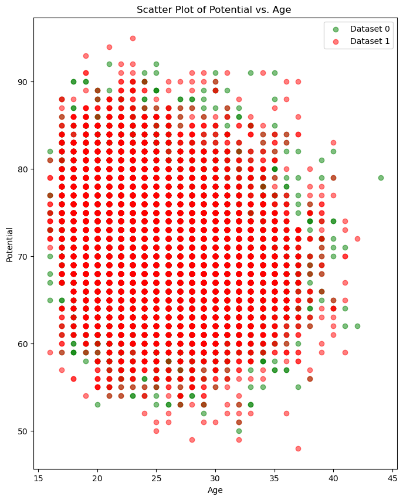

```python
import matplotlib.pyplot as plt
import pandas as pd


data0 = pd.read_csv("data0.csv")
data1 = pd.read_csv("data1.csv")

# Create scatter plots
plt.figure(figsize=(8,10))


plt.scatter(data0["Age"], data0["Potential"], alpha=0.5, label="Dataset 0", color='green')
plt.scatter(data1["Age"], data1["Potential"], alpha=0.5, label="Dataset 1", color='red')

plt.xlabel("Age")
plt.ylabel("Potential")
plt.title("Scatter Plot of Potential vs. Age ")
plt.legend()
plt.show()
```